# Avazu Click Through Rate Prediction

NPC

## Cleanup data

```r
source("Click_through.R")
train_set = read_data('train',limit=1000)
```

Data is much easier to process if we split it in to two smaller group.

> **Hypothesis:** We assume that ads from website and application have their own behaviour.  
> We can create two models based on different datasources independently.

```r
proof_split_site_app_domain(train_set)
remove(train_set)
```

### determine RARE level

> **Hypothesis:** We count population of each column. We assume it is rare if the count is less than 1%.

```r
train_web_set = read_data('train',data_source="web", limit=1000)
train_app_set = read_data('train',data_source="app", limit=1000)
```

```r
m_web = train_model_intersect_prob(train_web_set)
m_app = train_model_intersect_prob(train_app_set)
remove(train_web_set)
remove(train_app_set)
```

### replace rare categories with “RARE”

```r
source("Click_through_cleanup.R")
save_check_source_index(train_app_set)

data_sources = c("web", "app")
data_type    = "train"
replace_list = c("C1","banner_pos","site_category","app_category",
                 "device_model","device_type","device_conn_type",
                 "C14","C15","C16","C17","C18","C19","C20","C21")

for (data_source in data_sources) {
    for (col in replace_list) {
        cat("Clean", data_type, "set:", data_source, "-", col, "\n")
        clean_rare_category(col, data_type, data_source)
    }
}
```

## Plot and define predictors

We define predictors from clicl index that > 0, that means the feature has click > no-click

### Plot relationship between categories and save score

```
## [1] "C1 - site_category"
## Read [1] "clean/col_train_web_site_category.RData"
## [1] 25297228
## Read [1] "clean/col_train_web_C1.RData"
## [1] 25297228
## Read [1] "clean/col_train_web_click.RData"
## [1] 25297228
## [1] "Cal aggregate"
## [1] "Prepare for plotting"
```

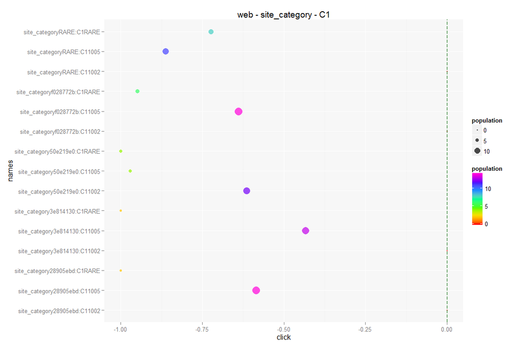

```
## [1] "C15 - site_category"
## Read [1] "clean/col_train_web_site_category.RData"
## [1] 25297228
## Read [1] "clean/col_train_web_C15.RData"
## [1] 25297228
## Read [1] "clean/col_train_web_click.RData"
## [1] 25297228
## [1] "Cal aggregate"
## [1] "Prepare for plotting"
```

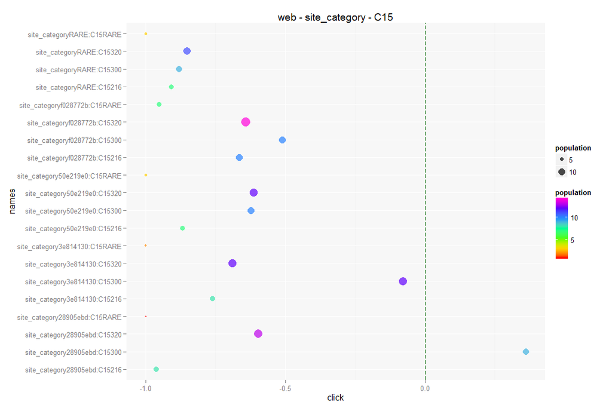

```
## [1] "C16 - site_category"
## Read [1] "clean/col_train_web_site_category.RData"
## [1] 25297228
## Read [1] "clean/col_train_web_C16.RData"
## [1] 25297228
## Read [1] "clean/col_train_web_click.RData"
## [1] 25297228
## [1] "Cal aggregate"
## [1] "Prepare for plotting"
```

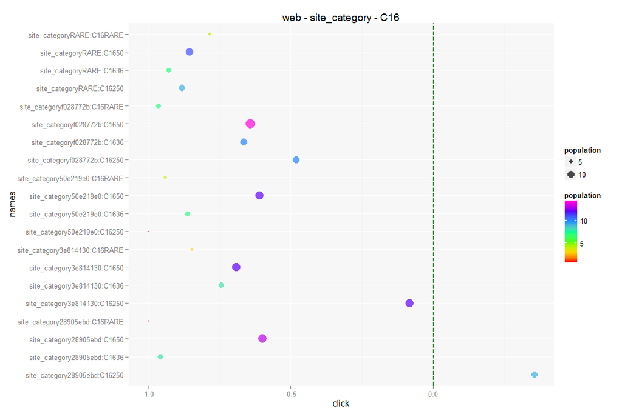

```
## [1] "C17 - site_category"
## Read [1] "clean/col_train_web_site_category.RData"
## [1] 25297228
## Read [1] "clean/col_train_web_C17.RData"
## [1] 25297228
## Read [1] "clean/col_train_web_click.RData"
## [1] 25297228
## [1] "Cal aggregate"
## [1] "Prepare for plotting"
```

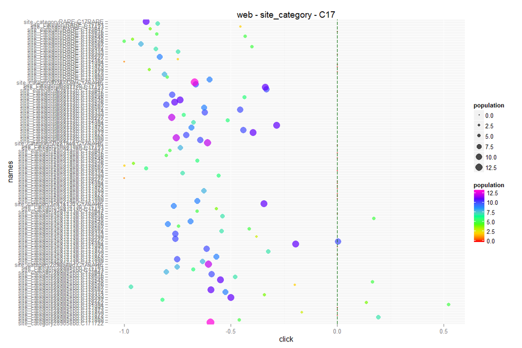

```
## [1] "C14 - site_category"
## Read [1] "clean/col_train_web_site_category.RData"
## [1] 25297228
## Read [1] "clean/col_train_web_C14.RData"
## [1] 25297228
## Read [1] "clean/col_train_web_click.RData"
## [1] 25297228
## [1] "Cal aggregate"
## [1] "Prepare for plotting"
```

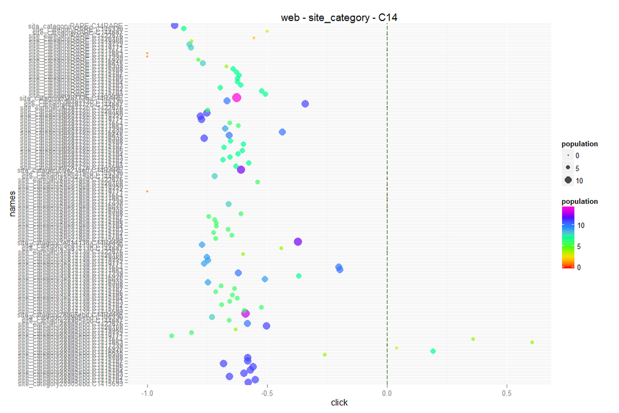

```
## [1] "C18 - site_category"
## Read [1] "clean/col_train_web_site_category.RData"
## [1] 25297228
## Read [1] "clean/col_train_web_C18.RData"
## [1] 25297228
## Read [1] "clean/col_train_web_click.RData"
## [1] 25297228
## [1] "Cal aggregate"
## [1] "Prepare for plotting"
```

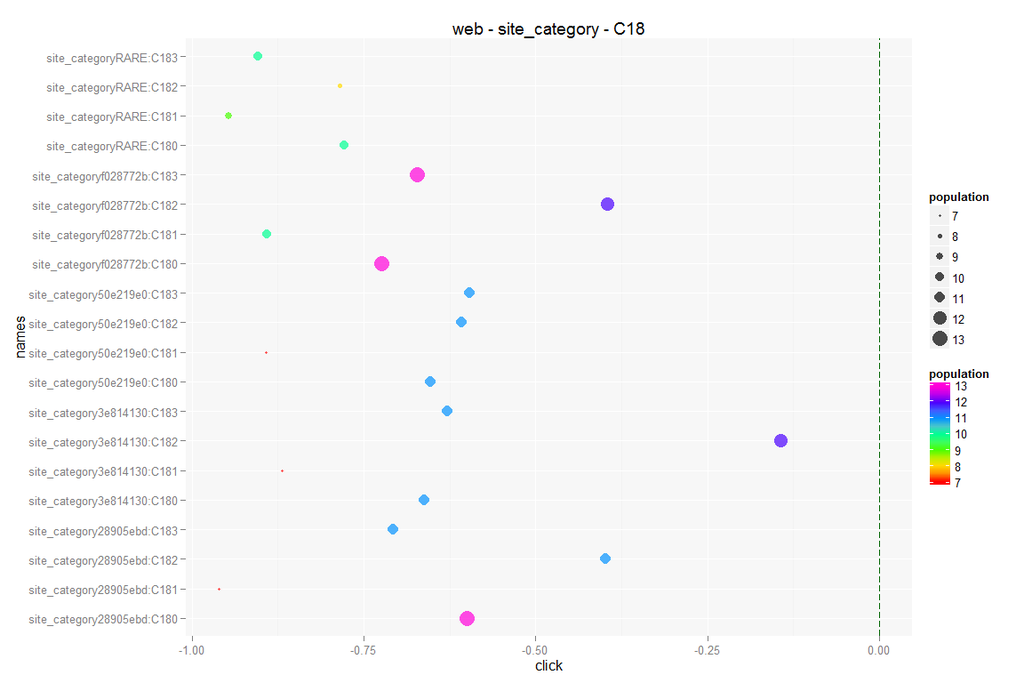

```
## [1] "C19 - site_category"
## Read [1] "clean/col_train_web_site_category.RData"
## [1] 25297228
## Read [1] "clean/col_train_web_C19.RData"
## [1] 25297228
## Read [1] "clean/col_train_web_click.RData"
## [1] 25297228
## [1] "Cal aggregate"
## [1] "Prepare for plotting"
```

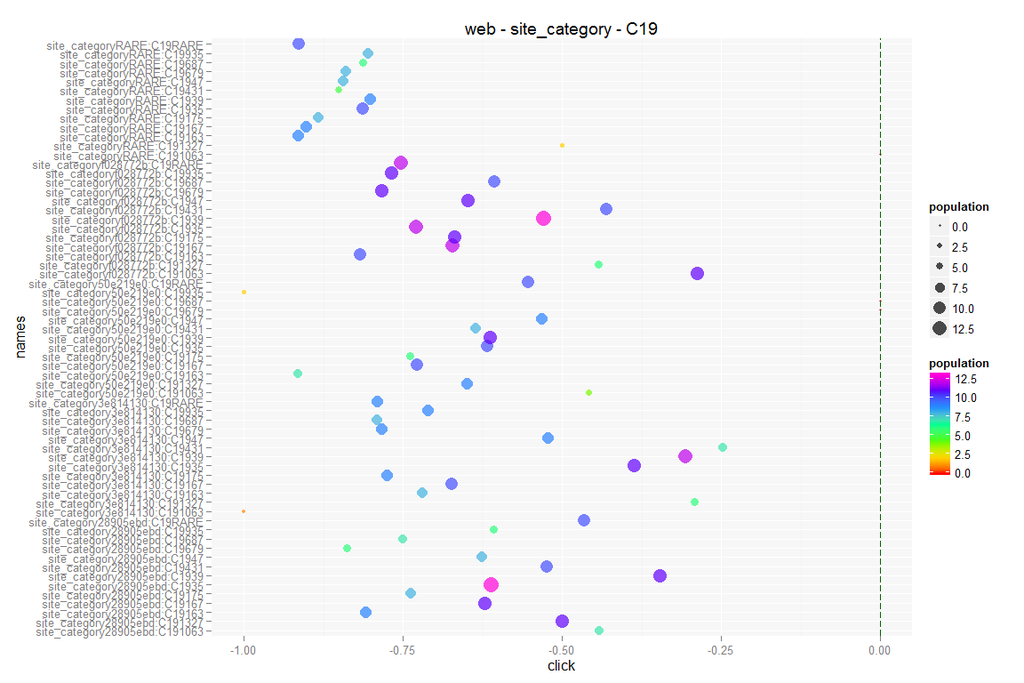

```
## [1] "C20 - site_category"
## Read [1] "clean/col_train_web_site_category.RData"
## [1] 25297228
## Read [1] "clean/col_train_web_C20.RData"
## [1] 25297228
## Read [1] "clean/col_train_web_click.RData"
## [1] 25297228
## [1] "Cal aggregate"
## [1] "Prepare for plotting"
```

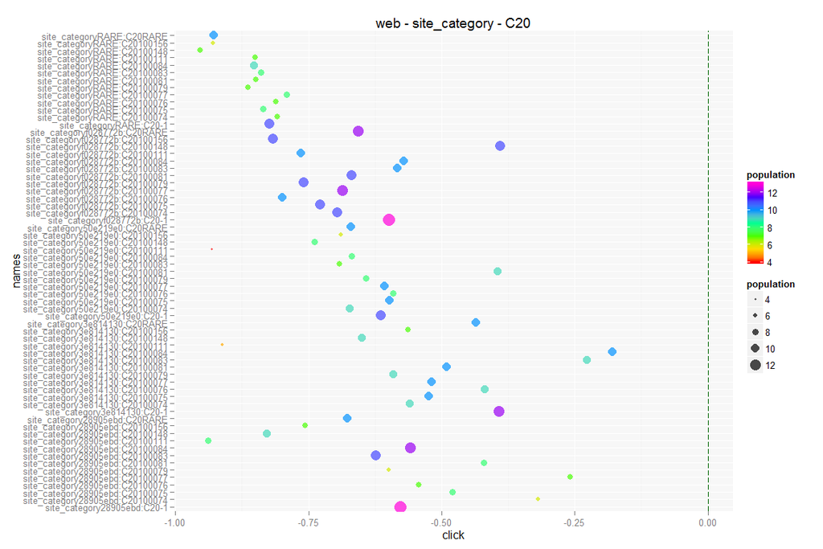

```
## [1] "C21 - site_category"
## Read [1] "clean/col_train_web_site_category.RData"
## [1] 25297228
## Read [1] "clean/col_train_web_C21.RData"
## [1] 25297228
## Read [1] "clean/col_train_web_click.RData"
## [1] 25297228
## [1] "Cal aggregate"
## [1] "Prepare for plotting"
```

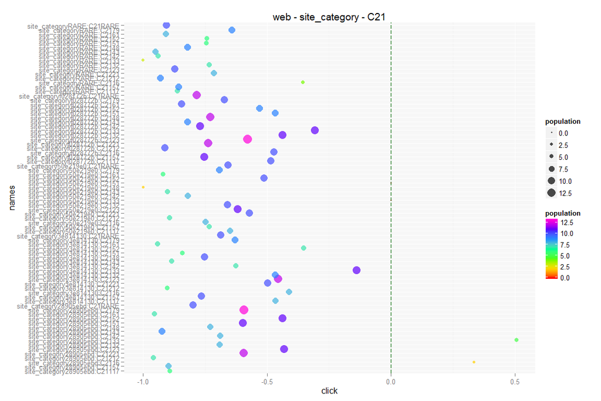

```
## [1] 1
```

```r
source("Click_through_plot.R")
plot_category_relation(data_source="web")
```

```
## [1] "C1 - app_category"
## Read [1] "clean/col_train_app_app_category.RData"
## [1] 15131739
## Read [1] "clean/col_train_app_C1.RData"
## [1] 15131739
## Read [1] "clean/col_train_app_click.RData"
## [1] 15131739
## [1] "Cal aggregate"
## [1] "Prepare for plotting"
```

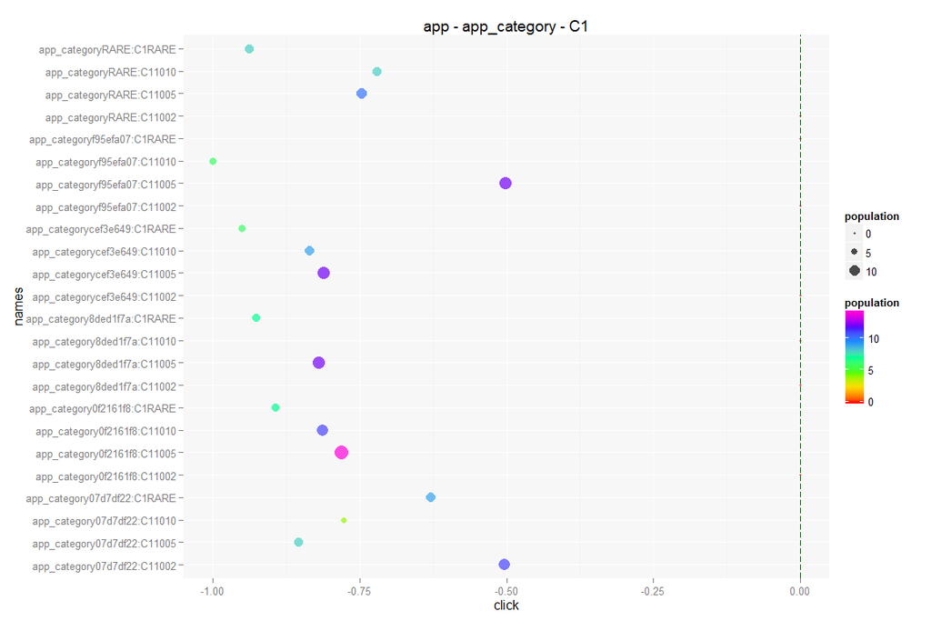

```
## [1] "C15 - app_category"
## Read [1] "clean/col_train_app_app_category.RData"
## [1] 15131739
## Read [1] "clean/col_train_app_C15.RData"
## [1] 15131739
## Read [1] "clean/col_train_app_click.RData"
## [1] 15131739
## [1] "Cal aggregate"
## [1] "Prepare for plotting"
```

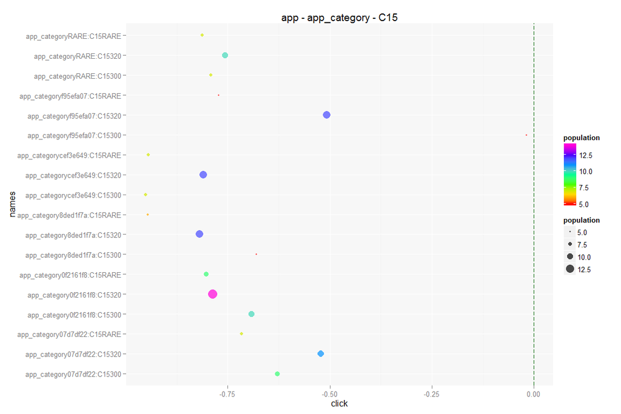

```
## [1] "C16 - app_category"
## Read [1] "clean/col_train_app_app_category.RData"
## [1] 15131739
## Read [1] "clean/col_train_app_C16.RData"
## [1] 15131739
## Read [1] "clean/col_train_app_click.RData"
## [1] 15131739
## [1] "Cal aggregate"
## [1] "Prepare for plotting"
```

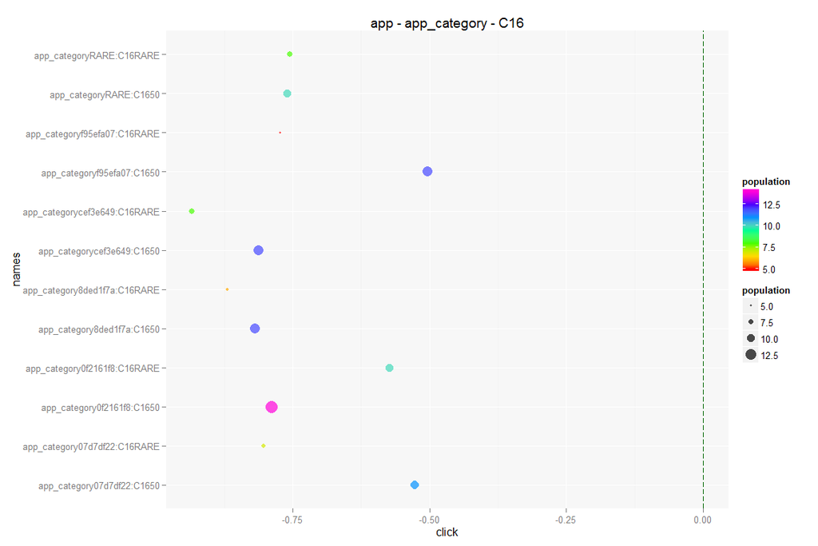

```
## [1] "C17 - app_category"
## Read [1] "clean/col_train_app_app_category.RData"
## [1] 15131739
## Read [1] "clean/col_train_app_C17.RData"
## [1] 15131739
## Read [1] "clean/col_train_app_click.RData"
## [1] 15131739
## [1] "Cal aggregate"
## [1] "Prepare for plotting"
```

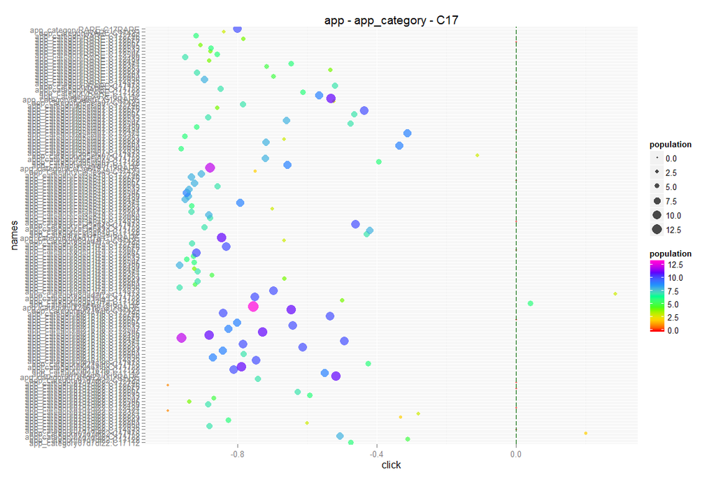

```
## [1] "C14 - app_category"
## Read [1] "clean/col_train_app_app_category.RData"
## [1] 15131739
## Read [1] "clean/col_train_app_C14.RData"
## [1] 15131739
## Read [1] "clean/col_train_app_click.RData"
## [1] 15131739
## [1] "Cal aggregate"
## [1] "Prepare for plotting"
```

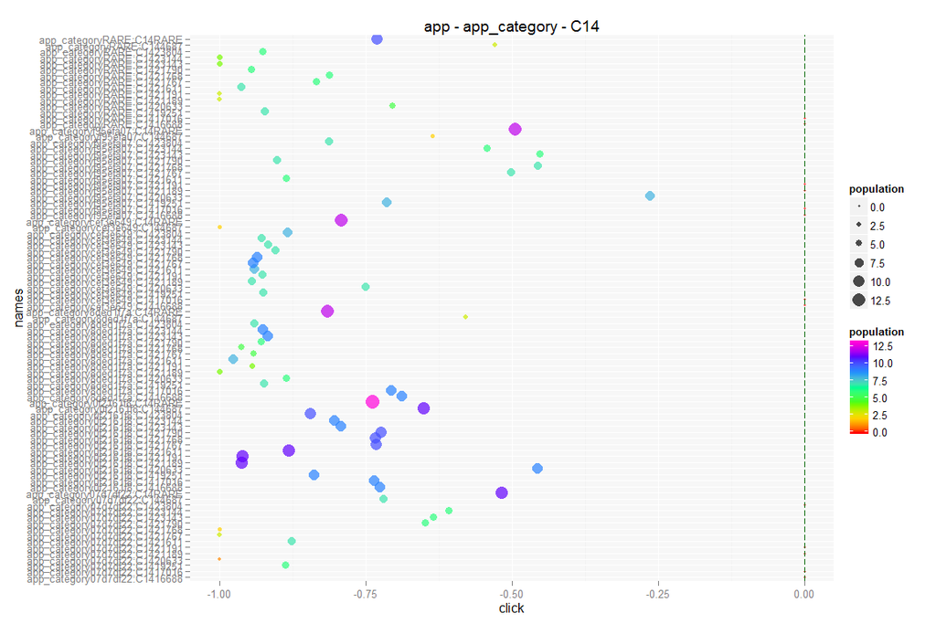

```
## [1] "C18 - app_category"
## Read [1] "clean/col_train_app_app_category.RData"
## [1] 15131739
## Read [1] "clean/col_train_app_C18.RData"
## [1] 15131739
## Read [1] "clean/col_train_app_click.RData"
## [1] 15131739
## [1] "Cal aggregate"
## [1] "Prepare for plotting"
```

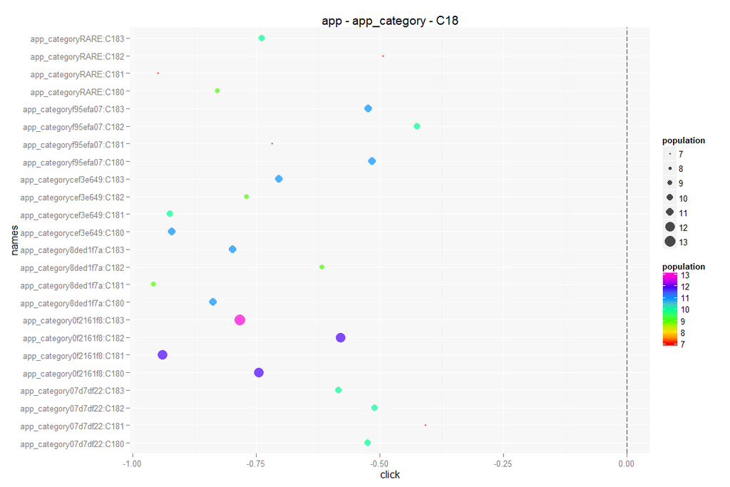

```
## [1] "C19 - app_category"
## Read [1] "clean/col_train_app_app_category.RData"
## [1] 15131739
## Read [1] "clean/col_train_app_C19.RData"
## [1] 15131739
## Read [1] "clean/col_train_app_click.RData"
## [1] 15131739
## [1] "Cal aggregate"
## [1] "Prepare for plotting"
```

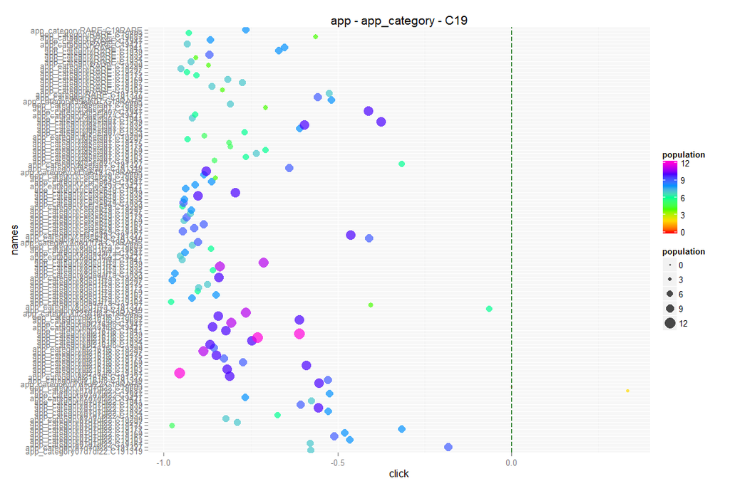

```
## [1] "C20 - app_category"
## Read [1] "clean/col_train_app_app_category.RData"
## [1] 15131739
## Read [1] "clean/col_train_app_C20.RData"
## [1] 15131739
## Read [1] "clean/col_train_app_click.RData"
## [1] 15131739
## [1] "Cal aggregate"
## [1] "Prepare for plotting"
```

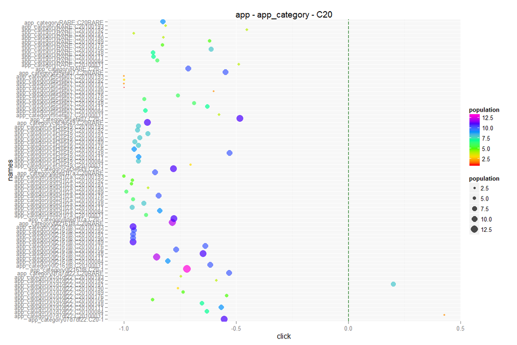

```
## [1] "C21 - app_category"
## Read [1] "clean/col_train_app_app_category.RData"
## [1] 15131739
## Read [1] "clean/col_train_app_C21.RData"
## [1] 15131739
## Read [1] "clean/col_train_app_click.RData"
## [1] 15131739
## [1] "Cal aggregate"
## [1] "Prepare for plotting"
```

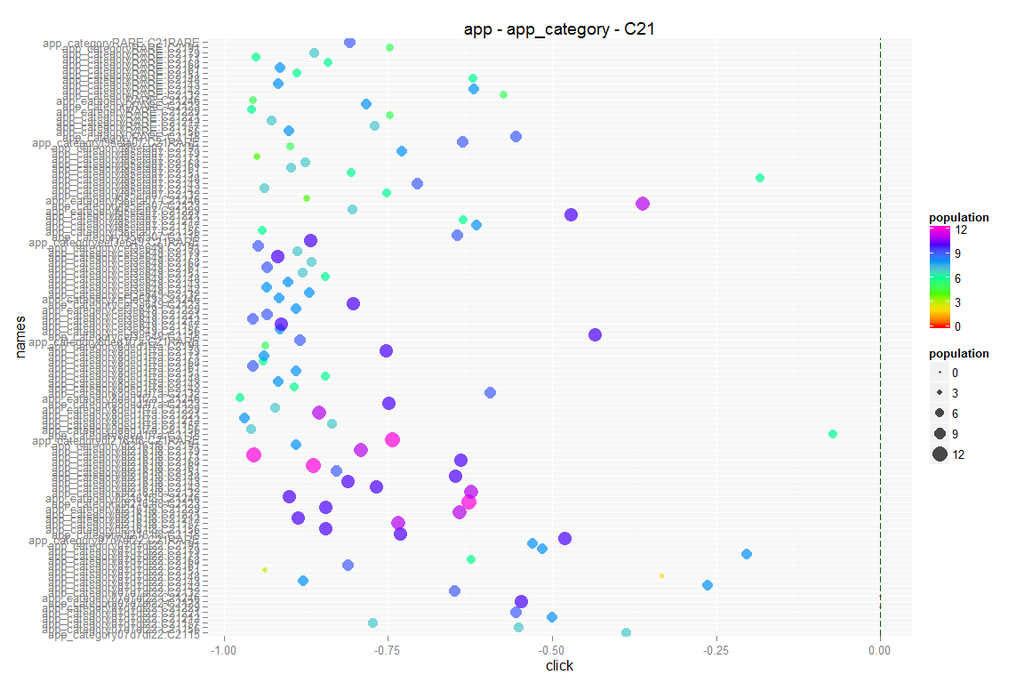

```
## [1] 1
```

```r
plot_category_relation(data_source="app")
```

### Plot relationship between banners and save score

improvement increase sampling for relationship data. If use 100% of training set, memory overflow.

```
## [1] "device_model - banner_pos"
## Read [1] "clean/col_train_web_banner_pos.RData"
## [1] 25297228
## Read [1] "clean/col_train_web_device_model.RData"
## [1] 25297228
## Read [1] "clean/col_train_web_click.RData"
## [1] 25297228
## [1] "Cal aggregate"
## [1] "Prepare for plotting"
```

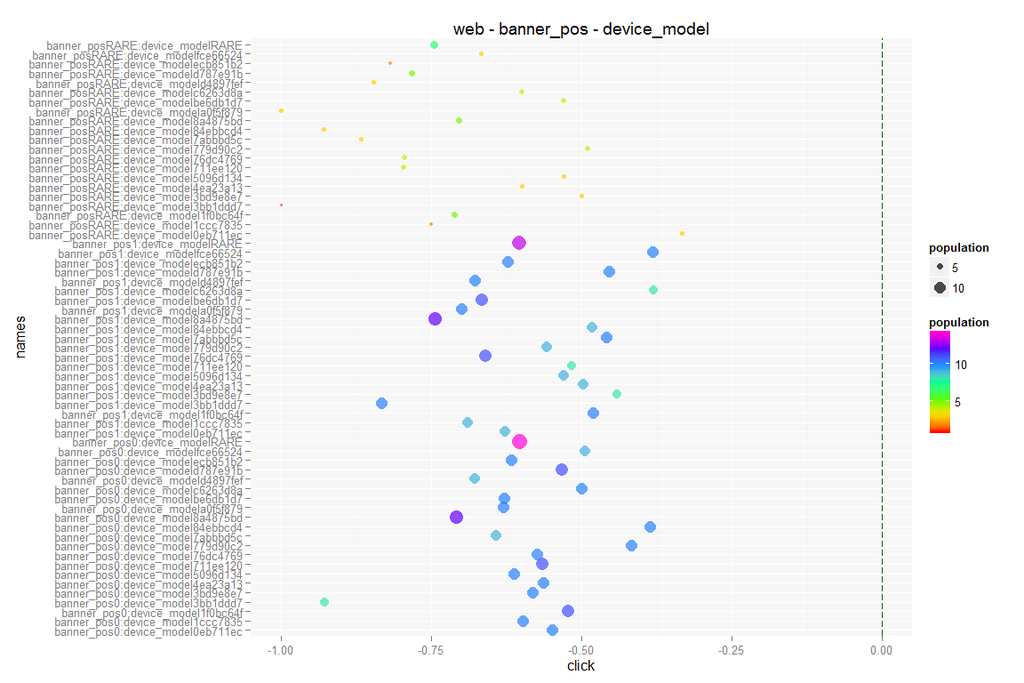

```
## [1] 1
```

```r
plot_banner_misc(data_source="web")
```

```
## [1] "device_model - banner_pos"
## Read [1] "clean/col_train_app_banner_pos.RData"
## [1] 15131739
## Read [1] "clean/col_train_app_device_model.RData"
## [1] 15131739
## Read [1] "clean/col_train_app_click.RData"
## [1] 15131739
## [1] "Cal aggregate"
## [1] "Prepare for plotting"
```

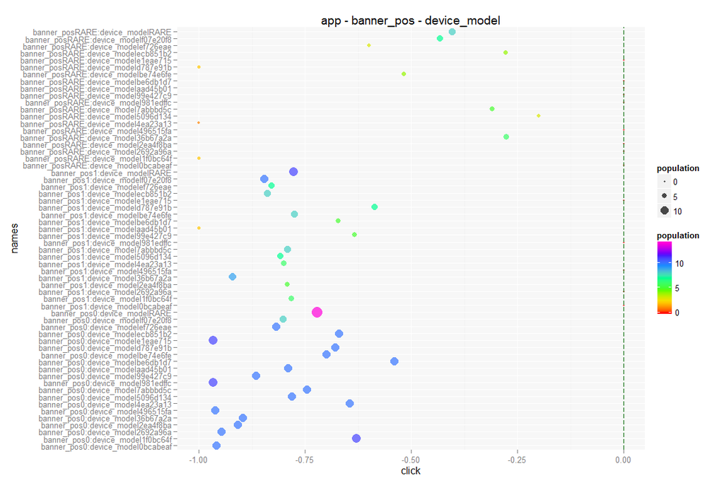

```
## [1] 1
```

```r
plot_banner_misc(data_source="app")
```

## Create model from predictors

```r
web_combo_list = list(
    c("banner_pos","C1"),
    c("banner_pos","C17"),
    c("device_model","C14"),
    c("device_model","C15"),
    c("device_model","C16"),
    c("device_model","C17"),
    c("device_model","C21"),
    c("site_category","C14"),
    c("site_category","C15"),
    c("site_category","C16"),
    c("site_category","C21")
)

app_combo_list = list(
    c("app_category","C15"),
    c("app_category","C17"),
    c("app_category","C19"),
    c("app_category","C20"),
    c("app_category","C21"),
    c("banner_pos","C1"),
    c("device_type","C20"),
    c("device_model","C17")
)
```

## Train and evaluate model

### Convert raw data into model structure

Set train/test ration to 0.6, separates models between web and app

```r
prep_model_relation_score(data_source="web", train_test_ratio=0.6)
prep_model_relation_score(data_source="app", train_test_ratio=0.6)
```

### Train

```r
model_web = train_model_relation_score(data_source="web")
model_web = train_model_relation_score(data_source="app")
```

### Evaluate model from ROC curve

plot ROC for web model

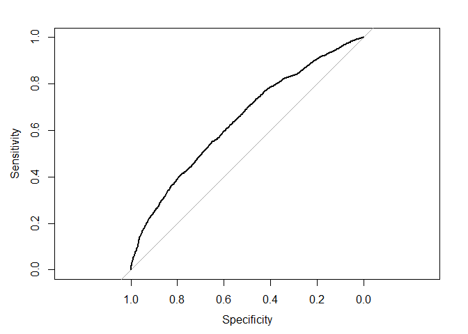

```
##
## Call:
## roc.default(response = testing_click, predictor = predictions,     algorithm = 2, plot = T)
##
## Data: predictions in 8116000 controls (testing_click 0) < 2002891 cases (testing_click 1).
## Area under the curve: 0.6449
```

```r
plot(roc_web)
```

plot ROC for app model

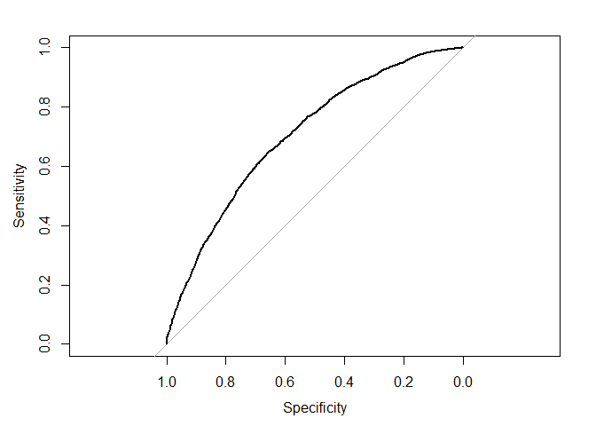

```
##
## Call:
## roc.default(response = testing_click, predictor = predictions,     algorithm = 2, plot = T)
##
## Data: predictions in 5310226 controls (testing_click 0) < 742469 cases (testing_click 1).
## Area under the curve: 0.705
```

```r
plot(roc_app)
```

## Predict Test set

Prepare test data and save to file

```r
data = prep_model_relation_score(data_source="web", mode="test")
```

Predict and save to file

```r
predict_model_relation_score()
```